# Polio Vaccine Trials

In 1954, the first successful Polio Vaccine was tested on a huge sample of young school children. Results of the vaccine trial are detailed in the table below.

|  | #Kids | #Polio Cases | #Paralytic Cases | #Fatalities |
| --- | --- | --- | --- | --- |
| Treatment Group | 200,745 | 82 | 33 | 0 |
| Control Group | 201,229 | 162 | 115 | 4 |
| **Subtotal** | 401,974 | 244 | 148 | 4 |
| Declined to Participate | 338,778 | n/a | n/a | n/a |
| Dropped Out | 8,484 | n/a | n/a | n/a |

Out of the 244 kids who got polio, only 82 (33.6%) were in the vaccine group. If the vaccine doesn’t work, that seems surprising.

The sizes of the two treatment groups are almost exactly the same. 49.9% of the kids got the vaccine, while 50.1% got a placebo.

Suppose that the vaccine doesn’t work. You’d expect around 49.9% of the kids who got polio to be in the vaccine group. How suprised should be be that the result was only 33.6%?

We can simulate the probability of getting only 33.6% by repeatedly simulating possible distributions of 244 sick kids to two equal sized groups. Imagine flipping a coin for each kid and if it is heads, assigning them to the treatment group, otherwise to the control group.

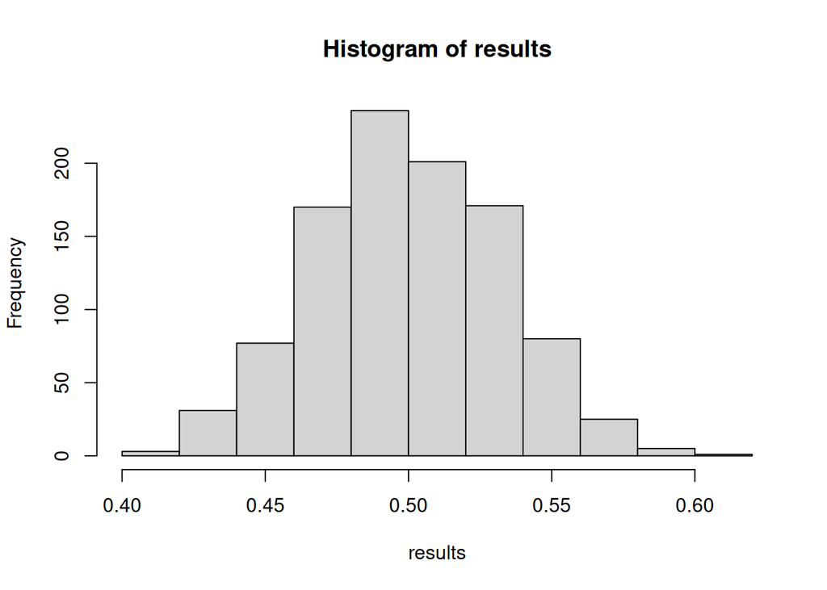

```r
results = c()
trials <- 1000
for (x in 1:trials) {
  simulated.result <- sample(c(0,1), size = 244, replace = TRUE)
  percent <- sum(simulated.result) / 244
  results <- c(results, percent)
}
hist(results)
```

```r
sum(results < 0.336) / trials
```

```
## [1] 0
```